# Masinõpe

Risto Hinno

jaanuar 2019

Käesolev peatükk annab põgusa näite, kuidas masinõpet kasutada. Masinõpe eesmärgiks on luua võimalikult hea algoritm määratud ülesande täitmiseks (https://en.wikipedia.org/wiki/Machine_learning). Ülesanded võivad olla erinevad: piltidelt objektide leidmine, toote hinna ennustamine jne. Tegemist on suure ja väga kiiresti areneva alaga. Kellel teema vastu rohkem huvi, siis soovitan teha läbi mõni e-kursus (https://www.coursera.org/learn/practical-machine-learning, kuid paha ei teeks ka kogu kursuste kogumiku läbimine: https://www.coursera.org/specializations/jhu-data-science). On olemas ka raamat, mis on küllaltki hea (alguses võib teooria hirmutav tunduda, see polegi nii tähtis. Raamatu tugevuses on koodinäidised): http://www-bcf.usc.edu/~gareth/ISL/ISLR%20Seventh%20Printing.pdf. Nüd asja juurde.

Näidise olen häbitult võtnud siit: https://machinelearningmastery.com/machine-learning-in-r-step-by-step/

## Paketid

Meil on vaja careti paketti ja e1071 paketti

```r
install.packages('caret', dependencies=T) #siin on vaja ka teisi pakette, millest see pakett sõltub
install.packages('e1071')
```

## Andmed

Esmalt laeme sisse andmed:

```r
library(caret)
library(e1071)
#see on Riga kaasasolev andmehulk, laeme selle sisse
data(iris)
# nimetame selle ümber
dataset <- iris
```

## Treening- ja testandmestik

Masinõppe üks baaskontseptsioone on treening- ja testandmestik. Selleks, et hinnata, kui hea meie mudel on, on meil vaja andmestikku, mida mudel ei ole näinud. Kui me kasutaks andmeid, mida mudel on näinud, saaksime liiga optimistliku hinnangu. Meie eesmärk on, et mudel õpiks üldistama, mis aitab saavutada täpseimat tulemust Me soovime vältida olukordi, kus mudel on midagi konkreetset “pähe tuupinud”.

Selleks loome treening- ja testandmestiku. Tavaliselt jäetakse testandmestikuks 10%-20% andmetest.

```r
# teeme indexi species veerust indeksi, mis võtab 80% väärtustest juhuslikult
validation_index <- createDataPartition(dataset$Species, p=0.80, list=FALSE)
# 20% valideerimisandmestiku loomine
validation <- dataset[-validation_index,]
#80% treeningandmetikuks
dataset <- dataset[validation_index,]
```

## Ülevaade andmetest

Viskame andmetele pilgu peale.

```r
dim(dataset)
```

```
## [1] 120   5
```

```r
head(dataset)
```

```
##   Sepal.Length Sepal.Width Petal.Length Petal.Width Species
## 1          5.1         3.5          1.4         0.2  setosa
## 2          4.9         3.0          1.4         0.2  setosa
## 3          4.7         3.2          1.3         0.2  setosa
## 4          4.6         3.1          1.5         0.2  setosa
## 5          5.0         3.6          1.4         0.2  setosa
## 6          5.4         3.9          1.7         0.4  setosa
```

```r
#Species tasemed
levels(dataset$Species)
```

```
## [1] "setosa"     "versicolor" "virginica"
```

```r
#Species jaotus (võid proovida seda teha ka tidyverse abiga)
percentage <- prop.table(table(dataset$Species)) * 100
cbind(freq=table(dataset$Species), percentage=percentage)
```

```
##            freq percentage
## setosa       40   33.33333
## versicolor   40   33.33333
## virginica    40   33.33333
```

```r
# kokkuvõte
summary(dataset)
```

```
##   Sepal.Length   Sepal.Width     Petal.Length    Petal.Width
##  Min.   :4.30   Min.   :2.000   Min.   :1.100   Min.   :0.100
##  1st Qu.:5.10   1st Qu.:2.800   1st Qu.:1.575   1st Qu.:0.300
##  Median :5.80   Median :3.000   Median :4.350   Median :1.300
##  Mean   :5.84   Mean   :3.073   Mean   :3.750   Mean   :1.197
##  3rd Qu.:6.40   3rd Qu.:3.325   3rd Qu.:5.100   3rd Qu.:1.800
##  Max.   :7.90   Max.   :4.100   Max.   :6.700   Max.   :2.500
##        Species
##  setosa    :40
##  versicolor:40
##  virginica :40
##
##
##
```

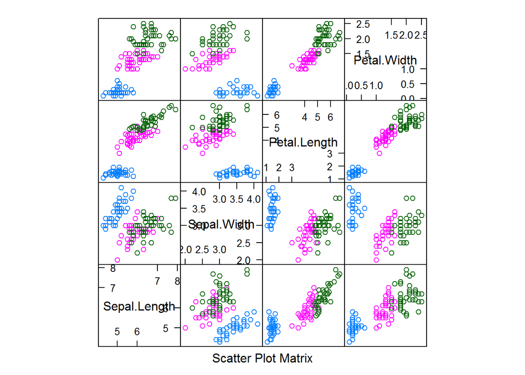

```r
# teeme sisendmuutujatest ja väljundmuutujast eraldi muutujad
x <- dataset[,1:4]
y <- dataset[,5]
# scatterplot maatriks, alusena kasutab paketti lattice
obj <- featurePlot(x=x, y =y, plot="pairs")
print(obj)
```

Ksutame ka ggploti, enne on vaja andmed pikka formaati viia.

```r
library(reshape2)
dataset_long=melt(dataset, id.vars=c("Species"))
```

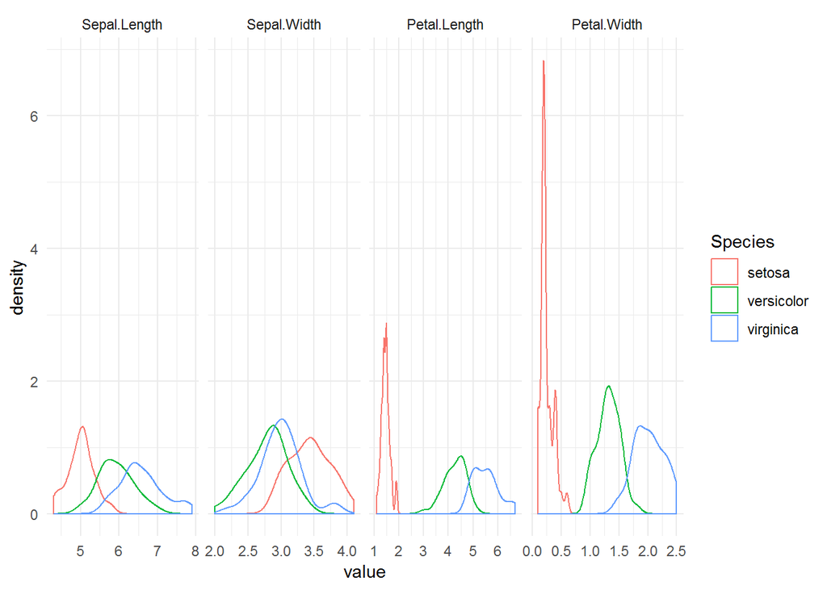

```r
ggplot(dataset_long, aes(x=value, group=Species, color=Species))+
  geom_density()+
  facet_grid(.~variable, scales="free")+
  theme_minimal()
```

## Ristvalideerimine

Lisaks testandmetele, mida peaksime ideaalsi kasutama ühe korra lõpliku mudeli hindamiseks, kasutame ka ristvalideerimist. See tähendab, et võtame treeningandmed ja jagame need n tükiks (meiep uhul 10-ks). Ja siis teeme nii: - võtame tükid 1-9, treenime mudeli - võtame tüki 10 ja hindame mudeli täpsust - võtame järgmised tükid 2-10, treenime uue mudeli - võtame tüki 1 ja hindame mudeli täpsust - kordame kuni kõik tükid on kasutatud nii treenimisel ja hindamisel

Ristvalideerimise plussiks on, et saame teada ka kui stabiilne täpsus on sõltuvalt mudelisse sattuvatest andmetest.

```r
#meie jagame andmed 10ks tükiks, "cv" tähendab cross-validationit ehk ristvalideerimist
control <- trainControl(method="cv", number=10)
#ütleme, kuidas mudeli headust mõõdame
metric <- "Accuracy"
```

Kui on soov kasutada muud muutrikat, siis võib selle kohta lugeda siit: https://topepo.github.io/caret/model-training-and-tuning.html#metrics

## Treenimine

Me kasutame erinevaid algoritem mudelite treenimiseks. Panen siia nende nimed (nende mudelite hingeelu lahkamine pole kahjuks selle kursuse eesmärk, see nõuaks eraldi kursust):

```r
set.seed(7) #see määrab, juhuslikkuse, mida mudeli treenimiseks kasutatakse. Ilma selleta saaksime iga kord kui mudelit treenimine veidi erineva tulemuse juhuslikkuse tõttu.
fit.lda <- train(Species~., data=dataset, method="lda", metric=metric, trControl=control)
# CART
set.seed(7)
fit.cart <- train(Species~., data=dataset, method="rpart", metric=metric, trControl=control)
# kNN
set.seed(7)
fit.knn <- train(Species~., data=dataset, method="knn", metric=metric, trControl=control)
# SVM
set.seed(7)
fit.svm <- train(Species~., data=dataset, method="svmRadial", metric=metric, trControl=control)
# Random Forest
set.seed(7)
fit.rf <- train(Species~., data=dataset, method="rf", metric=metric, trControl=control)
```

## Tulemused

caret pakett hoolitseb kogu treenimise ja hindamise eest, meie korjame ainult tulemused kokku. Ristvalideerimise tulemused.

```r
# väga mugav funktsioon tulemuste kokku korjamiseks
results <- resamples(list(lda=fit.lda, cart=fit.cart, knn=fit.knn, svm=fit.svm, rf=fit.rf))
summary(results)
```

```
##
## Call:
## summary.resamples(object = results)
##
## Models: lda, cart, knn, svm, rf
## Number of resamples: 10
##
## Accuracy
##           Min.   1st Qu.    Median      Mean   3rd Qu. Max. NA's
## lda  0.9166667 0.9166667 1.0000000 0.9666667 1.0000000    1    0
## cart 0.9166667 0.9166667 0.9166667 0.9416667 0.9791667    1    0
## knn  0.9166667 0.9375000 1.0000000 0.9750000 1.0000000    1    0
## svm  0.9166667 0.9375000 1.0000000 0.9750000 1.0000000    1    0
## rf   0.9166667 0.9166667 0.9583333 0.9583333 1.0000000    1    0
##
## Kappa
##       Min. 1st Qu. Median   Mean 3rd Qu. Max. NA's
## lda  0.875 0.87500 1.0000 0.9500 1.00000    1    0
## cart 0.875 0.87500 0.8750 0.9125 0.96875    1    0
## knn  0.875 0.90625 1.0000 0.9625 1.00000    1    0
## svm  0.875 0.90625 1.0000 0.9625 1.00000    1    0
## rf   0.875 0.87500 0.9375 0.9375 1.00000    1    0
```

Sama asi ka joonisel:

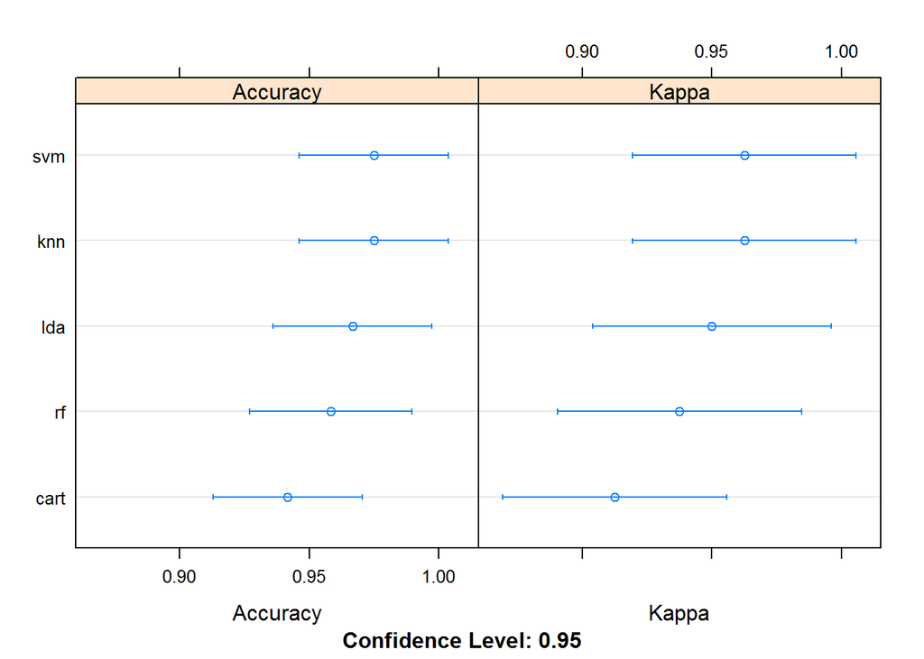

```r
dotplot(results)
```

## Testimine

Nüüd toome mängu andmed, mida mudel näinud pole, see peaks andma meile üsna reaalse hinnangu mudeli täpsusest.

```r
#siin kasutan ainult LDA algoritmi, teie ülesandeks jääb ka teiste kasutamine
predictions <- predict(fit.lda, validation)
confusionMatrix(predictions, validation$Species)
```

```
## Confusion Matrix and Statistics
##
##             Reference
## Prediction   setosa versicolor virginica
##   setosa         10          0         0
##   versicolor      0          9         0
##   virginica       0          1        10
##
## Overall Statistics
##
##                Accuracy : 0.9667
##                  95% CI : (0.8278, 0.9992)
##     No Information Rate : 0.3333
##     P-Value [Acc > NIR] : 2.963e-13
##
##                   Kappa : 0.95
##  Mcnemar's Test P-Value : NA
##
## Statistics by Class:
##
##                      Class: setosa Class: versicolor Class: virginica
## Sensitivity                 1.0000            0.9000           1.0000
## Specificity                 1.0000            1.0000           0.9500
## Pos Pred Value              1.0000            1.0000           0.9091
## Neg Pred Value              1.0000            0.9524           1.0000
## Prevalence                  0.3333            0.3333           0.3333
## Detection Rate              0.3333            0.3000           0.3333
## Detection Prevalence        0.3333            0.3000           0.3667
## Balanced Accuracy           1.0000            0.9500           0.9750
```